# Distance Between Two Points

Claire Fisher claire.a.fisher.vol@mail.mil

July 2016

This tutorial shows how to determine the distance between points and then map locations using R statistical software. This method can be an alternative to using ArcGIS, as it uses open source software and packages, specifically geosphere, ggplot2 and/or leaflet.

There are many applications for this kind of code, but this tutorial will use notional data of U.S. Starbucks locations and the geographic center of Washington, D.C.

There are 3 basic steps:

1. Prepare environment and data
2. Determine distance
3. Map data

## Step 1: Prepare Enviornment and Data

Open a new script file in R and paste the code block below to install the required packages and to load up the data; here, the data is on Starbucks locations and city centers.

```r
library(geosphere)
```

```r
library(ggplot2)
library(leaflet)
Starbucks <- read.csv("Starbucks.csv")
Cities <- read.csv("cities.csv")
```

Inspect the first 6 rows of the data

```r
head(Starbucks)
```

```
##   Latitude Longitude
## 1 21.87928 -159.4592
## 2 21.97116 -159.3809
## 3 21.97130 -159.3756
## 4 21.97947 -159.3493
## 5 22.07825 -159.3160
## 6 21.43479 -158.1846
##                                                                            Address
## 1               2360 Kiahuna Plantation Drive<br>Koloa, HI 96756<br>(808) 742-5144
## 2                3-2600 Kaumualii Highway #A8<br>Lihue, HI 96766<br>(808) 241-7034
## 3                        4303 Nawiliwili Road<br>Lihue, HI 96766<br>(808) 245-7562
## 4 LihueAirport  Unit 2  3901 Mokulele Loo<br>Lihue, HI 96766-970<br>(808) 245-8913
## 5                    4-831 Kuhio Highway #208<br>Kapaa, HI 96746<br>(808) 821-1334
## 6                     86 Farrington Highway<br>Waianae, HI 96792<br>(808) 697-8279
```

```r
head(Cities)
```

```
##             City     Lat      Lon
## 1 Washington, DC 38.9072 -77.0369
## 2   Philadelphia 39.9526 -75.1652
## 3       Richmond 37.5407 -77.4360
## 4      Baltimore 39.2904 -76.6122
## 5      Annapolis 38.9784 -76.4922
```

## Step 2: Determine Distance

### Step 2.1: The formula

The most accurate way to determine the distance between two points is the **‘Vincenty’ (ellipsoid) great circle distance**. This method assumes that the Earth is an ellipsoid (not a sphere):

distVincentyEllipsoid (*p1*, *p2*, a=6378137, b=6356752.3142, f=1/298.257223563))

*p1* and *p2* can be replaced with specific points from a data frame using the following syntax:

*p1*=cbind(Data Frame1.Longitude, Data Frame1.Latitude), *p2*=cbind(Data Frame2.Longitude, Data Frame2.Latitude)

a, and b are default values for output in **meters** (f is a constant). To get results in **miles**, use these values:

distVincentyEllipsoid (p1, p2, a=3963.190592, b=3949.90276423189)

### Step 2.2: Create the new dataframe

The first step will be to create a new data frame that will end up containing only the Starbucks near Washington, D.C.

```r
StarbucksinDC <- data.frame(Starbucks$Longitude, Starbucks$Latitude, Starbucks$Address)
```

Next a column with the distance between each Starbucks and Washington, D.C is added. DC is the first city in the Cities frame, so it’s specified by row number. The second column created is a factor variable with levels for how far away a Starbucks is from the city center: 25, 50, 100 or 200 miles away. Finally, the last line removes all the Starbucks that are more than 200 miles away.

```r
StarbucksinDC$DistDC <- distVincentyEllipsoid (cbind(Cities$Lon[1], Cities$Lat[1]),
                                       cbind(Starbucks$Longitude, Starbucks$Latitude),
                                       a=3963.190592, b=3949.90276423189)
StarbucksinDC$Category <- ordered(cut(StarbucksinDC$DistDC, c(0, 25, 50, 100, 200),
                                      labels=c("25 miles", "50 miles", "100 miles", "200 miles")))
StarbucksinDC<-StarbucksinDC[complete.cases(StarbucksinDC), ]
```

Now we have a list of the Starbucks within 200 miles of DC as well as the exact number of miles they are from the center of DC.

## Step 3: Map the Data

### Step 3.1: Map with ggplot2

Ggplot2’s maps provide a quick and easy way to display this information and make static images of the map. It might be more useful if you are doing multiple versions of the same map (i.e. for different city centers).

This code specifies the use of the US map and makes a selection of certain states to include in the base layer.

```r
map <- map_data("state")
```

```
##
##  # maps v3.1: updated 'world': all lakes moved to separate new #
##  # 'lakes' database. Type '?world' or 'news(package="maps")'.  #
```

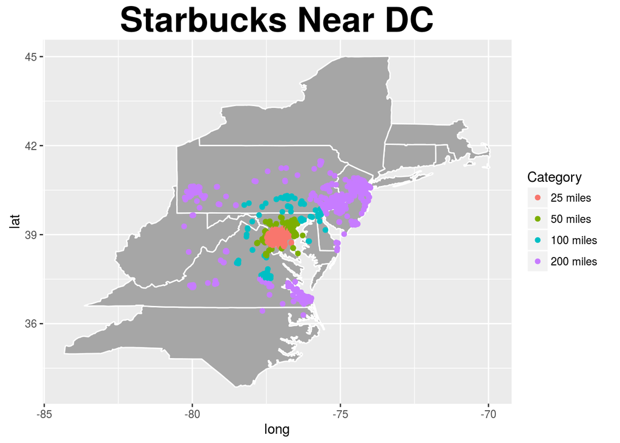

```r
mapb <- subset(map, region %in% c("massachusetts", "new york", "connecticut", "rhode island",
                                  "pennsylvania", "west virginia", "delaware", "new jersey",
                                  "virginia", "maryland", "north carolina", "district of columbia"))
basic_map <- ggplot()
basic_map <- basic_map +geom_polygon(data=mapb, aes(x=long, y=lat, group=group), color="white", fill="grey65")
dc <- basic_map + ggtitle("Starbucks Near DC") + theme(plot.title = element_text(face="bold", size=28))+ geom_point(data=StarbucksinDC, aes(x=Starbucks.Longitude, y=Starbucks.Latitude, color=Category))
dc
```

### Step 3.2: Map with leaflet

Leaflet allows the viewers to interact with the map: with this code, you can toggle different cities on/off and display an address by clicking on a point, in addition to zooming in and out.

The map is created using 5 different data frames. The first data frame is the distance from DC data frame created in step 2; the other 4 represent other cities created using the same syntax.

In the first group of code, the colors for the cities are specified. In the second part, the maps are created. Note that while the leaflet() line is using the StarbucksinDC data frame, the other circles are drawn from their respective city data frames using the “data=” option of addCircles(). Each command for addCircles() is given a group name, which is used again in the addLayersControl().

```r
library(leaflet)
colorDC <- colorFactor(palette=c("springgreen", "springgreen2", "springgreen3", "springgreen4"), domain = StarbucksinDC$DistDC)
colorPhil <- colorFactor(palette=c("palevioletred", "palevioletred2", "palevioletred3", "palevioletred4"), domain = StarbucksinPhil$Starbucks.DistPhil)
colorRich <- colorFactor(palette=c("deepskyblue", "royalblue2", "royalblue3", "navyblue"), domain = StarbucksinRich$Starbucks.DistRich)
colorBalt <- colorFactor(palette=c("magenta", "magenta3", "purple3", "purple4"), domain = StarbucksinBalt$Starbucks.DistBalt)
colorAnap <- colorFactor(palette=c("gold", "darkgoldenrod2", "darkgoldenrod3", "darkgoldenrod4"), domain = StarbucksinAnap$Starbucks.DistAnap)

master_map <- leaflet(StarbucksinDC) %>% addTiles() %>% addProviderTiles("CartoDB.Positron") %>% setView (lng = -77.0369, lat=38.9072, zoom=6) %>%
  addCircles (lng= ~Starbucks.Longitude, lat= ~Starbucks.Latitude, weight =3, opacity=.35, color=~colorDC(DistDC), popup=~Starbucks.Address, group="Wash DC", data=StarbucksinDC) %>%
  addCircles (lng= ~Starbucks.Longitude, lat= ~Starbucks.Latitude, weight =3, opacity=.35, color=~colorPhil(Starbucks.DistPhil), popup=~Starbucks.Address, group="Philadelphia", data=StarbucksinPhil) %>%
  addCircles (lng= ~Starbucks.Longitude, lat= ~Starbucks.Latitude, weight =3, opacity=.35, color=~colorRich(Starbucks.DistRich), popup=~Starbucks.Address, group="Richmond", data=StarbucksinRich) %>%
  addCircles (lng= ~Starbucks.Longitude, lat= ~Starbucks.Latitude, weight =3, opacity=.35, color=~colorBalt(Starbucks.DistBalt), popup=~Starbucks.Address, group="Baltimore", data=StarbucksinBalt) %>%
  addCircles (lng= ~Starbucks.Longitude, lat= ~Starbucks.Latitude, weight =3, opacity=.35, color=~colorAnap(Starbucks.DistAnap), popup=~Starbucks.Address, group="Annapolis", data=StarbucksinAnap) %>%
  addLayersControl(overlayGroups = c("Wash DC", "Philadelphia", "Richmond", "Baltimore", "Annapolis"), options = layersControlOptions(collapsed=FALSE))
master_map
```

[interactive chart not shown]